# VarMC Package

We include the all the functions available in our package, and the for each function we briefly explain its purpose and how its incorporated with eachother to eventually obtain the VaR value.

-Stock Dedection allows us to grab a specific stock’s data off the internet to then calculate its volatility measures under a 3-state HMM, the average of it, and its current returns.

-The Correlation matrix function allows us to merge the data we have from our given portfolio.

-The Covariance Matrix function allows us to turn the portfolio of our chosen stocks into a $n$x$n$ matrix.

-The Cholesky function lets us parse through the $n$x$n$ covariance matrix to end up with a lower-triangle matrix

-With the shock function, we use it to generate correlated shocks from the Cholesky factor

-We then apply these correlated shocks to the GBM through the simulated GBM function

-Then we finally compute the portfolio P&L from these simulated returns

-Achieving the VaR value.

# Collecting stock data

Through the `stock_detection` function, lets say we want to grab the historical data of Apple,

```
#> Rows: 3,772
#> Columns: 8
#> $ symbol   <chr> "AAPL", "AAPL", "AAPL", "AAPL", "AAPL", "AAPL", "AAPL", "AAPL", "AA…
#> $ date     <date> 2011-01-03, 2011-01-04, 2011-01-05, 2011-01-06, 2011-01-07, 2011-0…
#> $ open     <dbl> 11.63000, 11.87286, 11.76964, 11.95429, 11.92821, 12.10107, 12.3171…
#> $ high     <dbl> 11.79500, 11.87500, 11.94071, 11.97321, 12.01250, 12.25821, 12.3200…
#> $ low      <dbl> 11.60143, 11.71964, 11.76786, 11.88929, 11.85357, 12.04179, 12.1239…
#> $ close    <dbl> 11.77036, 11.83179, 11.92857, 11.91893, 12.00429, 12.23036, 12.2014…
#> $ volume   <dbl> 445138400, 309080800, 255519600, 300428800, 311931200, 448560000, 4…
#> $ adjusted <dbl> 9.874909, 9.926448, 10.007645, 9.999556, 10.071166, 10.260832, 10.2…
```

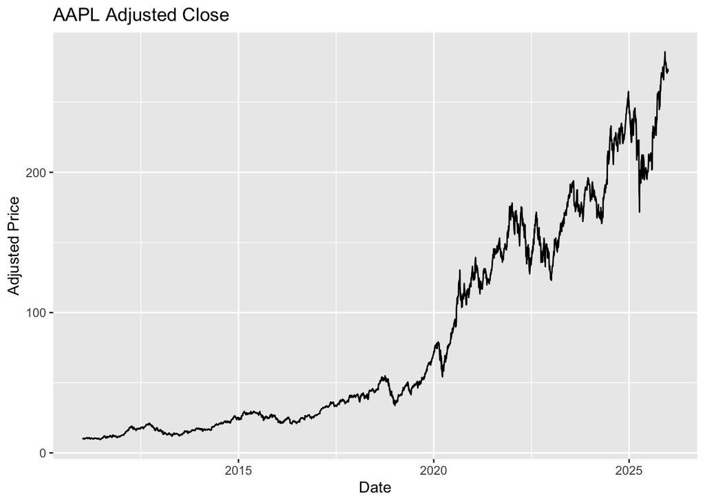

from here on, as we can see this is the stock info of Apple during 2011 to 2026.

```r
stock_detection(apple)

cat(out$current_volatility)
cat(out$current_mean)
```

[output not shown]

# Correlation Matrix and Covariance matrix

Let’s say our portfolio consists of Apple, Nvidia, Tesla, and Visa.

```r
apple <- tq_get("AAPL", from = "2011-01-01", to = "2026-01-01")
nvidia <- tq_get("NVDA", from = "2011-01-01", to = "2026-01-01")
tesla <- tq_get("TSLA", from = "2011-01-01", to = "2026-01-01")
visa <- tq_get("V", from = "2011-01-01", to = "2026-01-01")

portfolio <- list(
  stock_detection(nvidia),
  stock_detection(apple),
  stock_detection(tesla),
  stock_detection(visa)
)
```

```
#> converged at iteration 192 with logLik: 10317.54
#> converged at iteration 485 with logLik: 7622.497
#> converged at iteration 282 with logLik: 11033.88
```

```r
regime_vols <- sapply(portfolio, function(x) x$current_volatility)
regime_means <- sapply(portfolio, function(x) x$current_mean)
corr_mat <- correlation_matrix_of_stock_portfolio(portfolio)
cov_mat <- covariance_matrix_of_stock_portfolio(regime_vols, corr_mat)

corr_mat
```

```
#>           return.x  return.y  return.x  return.y
#> return.x 1.0000000 0.4875758 0.3894472 0.4412988
#> return.y 0.4875758 1.0000000 0.3844810 0.4932150
#> return.x 0.3894472 0.3844810 1.0000000 0.3210019
#> return.y 0.4412988 0.4932150 0.3210019 1.0000000
```

```r
cov_mat
```

```
#>              [,1]         [,2]         [,3]         [,4]
#> [1,] 2.357531e-04 7.116042e-05 1.262949e-04 4.852558e-05
#> [2,] 7.116042e-05 9.035150e-05 7.718827e-05 3.357479e-05
#> [3,] 1.262949e-04 7.718827e-05 4.460849e-04 4.855408e-05
#> [4,] 4.852558e-05 3.357479e-05 4.855408e-05 5.128834e-05
```

# Geometric Brownian Motion Simulations

```
#>             [,1]        [,2]        [,3]        [,4]
#> [1,] 0.015354252 0.000000000 0.000000000 0.000000000
#> [2,] 0.004634574 0.008298929 0.000000000 0.000000000
#> [3,] 0.008225405 0.004707478 0.018875043 0.000000000
#> [4,] 0.003160400 0.002280738 0.000626329 0.005975463
```

And then for the case of 10,000 simulations

```
#>  [1]  0.0066487858  0.0060552123  0.0235268239  0.0021144627 -0.0042232526
#>  [6] -0.0037181810 -0.0001264390 -0.0041705067 -0.0073213406  0.0001634224
#> [11] -0.0194014272 -0.0079786812  0.0007566600  0.0036878630  0.0413368557
#> [16] -0.0024652487  0.0237460912  0.0024788167  0.0305522045 -0.0031829043
#> [21] -0.0345473239 -0.0184867910  0.0023462765 -0.0087702098 -0.0129871156
#> [26] -0.0042873143 -0.0046076661 -0.0083090541 -0.0208187739 -0.0053992399
#> [31] -0.0213370081 -0.0015864253 -0.0125065526 -0.0203192985 -0.0268313071
#> [36] -0.0008559309 -0.0054256375 -0.0095640189  0.0060157045 -0.0017547611
#> [41] -0.0121755575  0.0062133010  0.0216573721  0.0104999919  0.0019526948
#> [46] -0.0026096936 -0.0088821250  0.0130478974  0.0287607769  0.0106197434
```

Finally, by applying the correlated shocks into out GBM formula, we get the simulated GBM returns

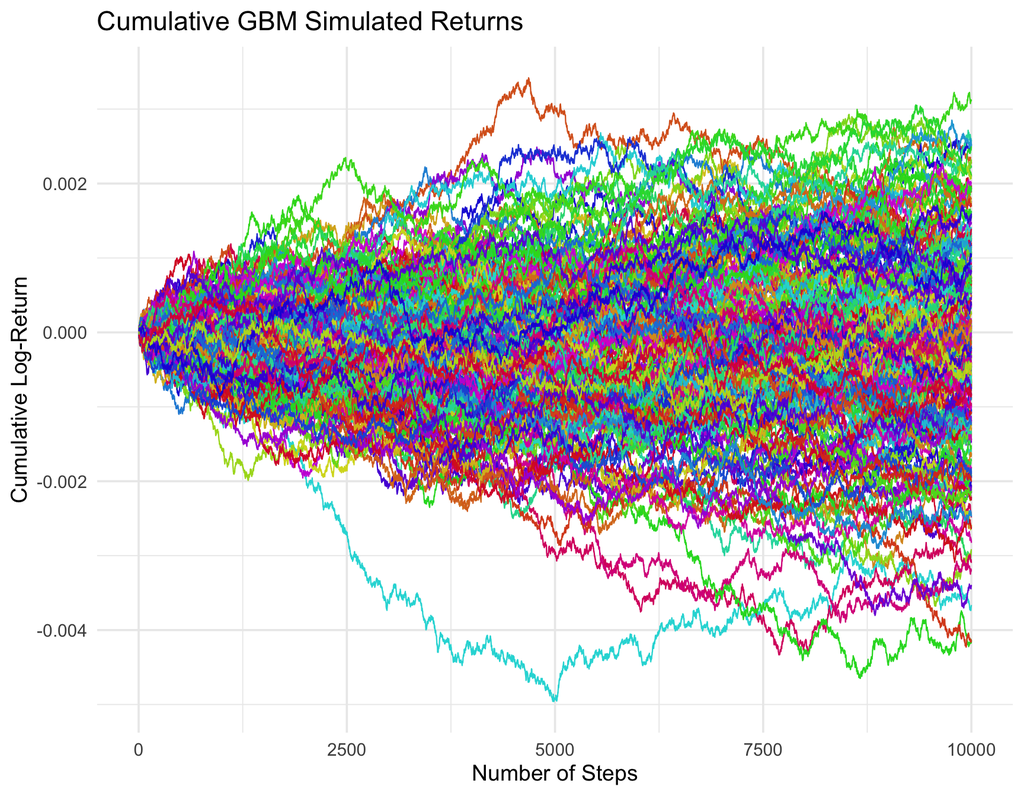

# VaR value

Finally we will be able to calculate our Var value by computing the portfolio’s simulated P&L

```
#> [1] -16137.41
#>     lower     upper
#> -16160.95 -16109.57
```

This is the final value of money that we lose if we were to choose model, under 95% C.I., time horizon of 10 days, and a even 25% weight distribution in our stock portfolio.

The bootstraps also shows us the C.I. of 95% under 500 boostrapping resamples.

# Backteting

Here we do our backtesting through Kupiec’s test through the same parameters used in previous examples.

```
#> Kupiec POF Backtest Results
#> ----------------------------
#> Total Observations:     3263
#> Expected Violations:    163.15
#> Observed Violations:    1378
#> Expected Rate:          0.05
#> Observed Rate:          0.4223
#> LR Statistic:           NaN
```

# Comments

The backtesting strategy of using Kupiec’s test is not as likely as we hoped for a big reason of that we believe is due to the fact that when we split out data into 3 states, and the Low-volatility being the most probable, that takes up a big portion of the data, and our backtesting function also works with rolling windows instead of HMM regime vols, thus it could be underestimated.

The work was evenly distributed between the two members of the team as Jeffrey focused more on the start of the project(everything before Cholesky) and Faye worked on the end(after GBM). the work in the middle was worked by ex-member Mahan.

There majority of A.I help was used in testcases, roxygen, Rmd, ggplot, and the Backtesting portion.

# References

Dancho, Matt, and Davis Vaughan. 2023. *Tidyquant: Tidy Quantitative Financial Analysis*. https://business-science.github.io/tidyquant/.

Ding, Yi, Dimos Kambouroudis, and David G. McMillan. 2025. “Forecasting Realised Volatility Using Regime-Switching Models.” *International Review of Economics and Finance* 101: 104171. https://doi.org/10.1016/j.iref.2025.104171.

Halilbegovic, Sanel, and Mia Vehabovic. 2016. “Backtesting Value at Risk Forecast: The Case of Kupiec POF-Test.” *European Journal of Economic Studies* 17 (3): 393–404. https://doi.org/10.13187/es.2016.17.393.

Visser, Ingmar, and Maarten Speekenbrink. 2010. “depmixS4: An R Package for Hidden Markov Models.” *Journal of Statistical Software* 36 (7): 1–21. https://doi.org/10.18637/jss.v036.i07.

Voss, Jochen. 2013. *An Introduction to Statistical Computing: A Simulation-Based Approach*. John Wiley & Sons.